# Set up

```r
# install.packages("corrplot")
# install.packages("car")
# install.packages("stargazer")
# install.packages("sandwich")
# install.packages("robustbase")

library(car)
library(corrplot)
library(stargazer)
library(sandwich)
library(lmtest)
library(robustbase)
```

# Introduction

The great state of North Carolina and its 100 counties make for a diverse place, with both urban and rural, richer and poorer areas. Today, the state capital of Raleigh is a thriving research-based region, while the city of Charlotte is the 2nd largest Banking center in the US after New York. However, there are obvious concerns related to violence and crime statistics. With the upcoming elections in most of the 13 congressional districts of the state, our agency has been hired to provide a detailed research on crime rates in the state and how best to provide an actionable set of policy recommendations -- so that the candidate could lay those out to the election going public and hopefully also sway indepenedents in their favor.

# Research question

Our project aims to determine whether wage increases in one industry are able to reduce crime. It is commonly known that crime tends to correlate with factors such as higher population density and urban areas; however, there has been less research on the effect of wages on an area's crime rate.

Nonetheless, we accept that while government policies are able to affect other industries (e.g., through the minimum wage), if most of the employees in an industry already make more that the minimum wage, that effect is significantly dampened. However, government wages can be potentially affected by policy much more directly.

Thus given this potentially actionable policy recommendation that might be obtained from our research, **we seek to determine whether wage increases in government jobs are able to reduce crime.**

Based on the results of this analysis, we aim to recommend whether our political compaign should advocate for higher government wages as well as potentially continue research in wages within other industries. Note that whether or not economic prosperity has an effect on crime, it continues to be a worthy goal with many potential positive effects in other parts of our constituents lives; additional research will be required to determine the effects on other aspects of quality-of-life.

# Methodology and EDA

We use data from C. Cornwell and W. Trumball (1994), “Estimating the Economic Model of Crime with Panel Data,” Review of Economics and Statistics 76, 360-366.

We start by reading in the data and checking then number of blank cells. We see that almost all of the columns have 6 nulls which are caused by reading in empty rows at the bottom of the dataframe. We remove these data points.

```r
data <- read.table("crime_v2.csv", header=TRUE, sep=",")
colSums(is.na(data))
tail(data, 10)
data <- na.omit(data, cols="county")  # Remove empty rows read into bottom of table
```

**county**

6

**year**

6

**crmrte**

6

**prbarr**

6

**prbconv**

0

**prbpris**

6

**avgsen**

6

**polpc**

6

**density**

6

**taxpc**

6

**west**

6

**central**

6

**urban**

6

**pctmin80**

6

**wcon**

6

**wtuc**

6

**wtrd**

6

**wfir**

6

**wser**

6

**wmfg**

6

**wfed**

6

**wsta**

6

**wloc**

6

**mix**

6

**pctymle**

6

|  | county | year | crmrte | prbarr | prbconv | prbpris | avgsen | polpc | density | taxpc | ... | wtuc | wtrd | wfir | wser | wmfg | wfed | wsta | wloc | mix | pctymle |
| --- | --- | --- | --- | --- | --- | --- | --- | --- | --- | --- | --- | --- | --- | --- | --- | --- | --- | --- | --- | --- | --- |
| 88 | 193 | 87 | 0.0235277 | 0.266055 | 0.588859022 | 0.423423 | 5.86 | 0.00117887 | 0.8138298 | 28.51783 | ... | 480.1948 | 268.3836 | 365.0196 | 295.9352 | 295.63 | 468.26 | 337.88 | 348.74 | 0.11050157 | 0.07819394 |
| 89 | 193 | 87 | 0.0235277 | 0.266055 | 0.588859022 | 0.423423 | 5.86 | 0.00117887 | 0.8138298 | 28.51783 | ... | 480.1948 | 268.3836 | 365.0196 | 295.9352 | 295.63 | 468.26 | 337.88 | 348.74 | 0.11050157 | 0.07819394 |
| 90 | 195 | 87 | 0.0313973 | 0.201397 | 1.670519948 | 0.470588 | 13.02 | 0.00445923 | 1.7459893 | 53.66693 | ... | 377.9356 | 246.0614 | 411.4330 | 296.8684 | 392.27 | 480.79 | 303.11 | 337.28 | 0.15612382 | 0.07945071 |
| 91 | 197 | 87 | 0.0141928 | 0.207595 | 1.182929993 | 0.360825 | 12.23 | 0.00118573 | 0.8898810 | 25.95258 | ... | 341.8803 | 182.8020 | 348.1432 | 212.8205 | 322.92 | 391.72 | 385.65 | 306.85 | 0.06756757 | 0.07419893 |
| 92 | NA | NA | NA | NA |  | NA | NA | NA | NA | NA | ... | NA | NA | NA | NA | NA | NA | NA | NA | NA | NA |
| 93 | NA | NA | NA | NA |  | NA | NA | NA | NA | NA | ... | NA | NA | NA | NA | NA | NA | NA | NA | NA | NA |
| 94 | NA | NA | NA | NA |  | NA | NA | NA | NA | NA | ... | NA | NA | NA | NA | NA | NA | NA | NA | NA | NA |
| 95 | NA | NA | NA | NA |  | NA | NA | NA | NA | NA | ... | NA | NA | NA | NA | NA | NA | NA | NA | NA | NA |
| 96 | NA | NA | NA | NA |  | NA | NA | NA | NA | NA | ... | NA | NA | NA | NA | NA | NA | NA | NA | NA | NA |
| 97 | NA | NA | NA | NA | ` | NA | NA | NA | NA | NA | ... | NA | NA | NA | NA | NA | NA | NA | NA | NA | NA |

Next, we take a look at the datatypes for each of the columns and notice that one of the colums `prbconv`, probability of conviction was actually loaded as a factor. We convert this into a numeric instead.

```r
sapply(data, class)
data$prbconv <- as.numeric(as.character(data$prbconv))  # Convert factor column to numeric
```

**county**

'integer'

**year**

'integer'

**crmrte**

'numeric'

**prbarr**

'numeric'

**prbconv**

'factor'

**prbpris**

'numeric'

**avgsen**

'numeric'

**polpc**

'numeric'

**density**

'numeric'

**taxpc**

'numeric'

**west**

'integer'

**central**

'integer'

**urban**

'integer'

**pctmin80**

'numeric'

**wcon**

'numeric'

**wtuc**

'numeric'

**wtrd**

'numeric'

**wfir**

'numeric'

**wser**

'numeric'

**wmfg**

'numeric'

**wfed**

'numeric'

**wsta**

'numeric'

**wloc**

'numeric'

**mix**

'numeric'

**pctymle**

'numeric'

Taking a look at the summary of our data, we see that

1. `year` is a constant and can be removed as the min, median, mean, max, etc. are all the same
2. `prbarr`, probability of arrest, and `prbconv`, probability of conviction, have maximum values that are larger than 100%. Probabilities shouldn't have values over 100%. As we do not know if these data points were miss-entered and were supposed to be very low (e.g., 1.09 should have been 0.109) or were supposed to simply be at 100% (very high), it is safer for us just to remove these data points.
3. `wser`, wages in the services industry, seems to have a maximum significantly larger than the median, mean and the quartiles, which seems to indicate that there is a significant outlier. If we decide to use this data point in our models, we'll have to take a closer look to determine whether this point should be retained or removed.

```r
summary(data)
data = subset(data, select=-c(year))
data = data[data$prbarr <= 1.0 & data$prbconv <= 1.0,]
```

```
     county           year        crmrte             prbarr
 Min.   :  1.0   Min.   :87   Min.   :0.005533   Min.   :0.09277
 1st Qu.: 52.0   1st Qu.:87   1st Qu.:0.020927   1st Qu.:0.20568
 Median :105.0   Median :87   Median :0.029986   Median :0.27095
 Mean   :101.6   Mean   :87   Mean   :0.033400   Mean   :0.29492
 3rd Qu.:152.0   3rd Qu.:87   3rd Qu.:0.039642   3rd Qu.:0.34438
 Max.   :197.0   Max.   :87   Max.   :0.098966   Max.   :1.09091
    prbconv           prbpris           avgsen           polpc
 Min.   :0.06838   Min.   :0.1500   Min.   : 5.380   Min.   :0.0007459
 1st Qu.:0.34541   1st Qu.:0.3648   1st Qu.: 7.340   1st Qu.:0.0012308
 Median :0.45283   Median :0.4234   Median : 9.100   Median :0.0014853
 Mean   :0.55128   Mean   :0.4108   Mean   : 9.647   Mean   :0.0017022
 3rd Qu.:0.58886   3rd Qu.:0.4568   3rd Qu.:11.420   3rd Qu.:0.0018768
 Max.   :2.12121   Max.   :0.6000   Max.   :20.700   Max.   :0.0090543
    density            taxpc             west           central
 Min.   :0.00002   Min.   : 25.69   Min.   :0.0000   Min.   :0.0000
 1st Qu.:0.54741   1st Qu.: 30.66   1st Qu.:0.0000   1st Qu.:0.0000
 Median :0.96226   Median : 34.87   Median :0.0000   Median :0.0000
 Mean   :1.42884   Mean   : 38.06   Mean   :0.2527   Mean   :0.3736
 3rd Qu.:1.56824   3rd Qu.: 40.95   3rd Qu.:0.5000   3rd Qu.:1.0000
 Max.   :8.82765   Max.   :119.76   Max.   :1.0000   Max.   :1.0000
     urban            pctmin80           wcon            wtuc
 Min.   :0.00000   Min.   : 1.284   Min.   :193.6   Min.   :187.6
 1st Qu.:0.00000   1st Qu.: 9.845   1st Qu.:250.8   1st Qu.:374.6
 Median :0.00000   Median :24.312   Median :281.4   Median :406.5
 Mean   :0.08791   Mean   :25.495   Mean   :285.4   Mean   :411.7
 3rd Qu.:0.00000   3rd Qu.:38.142   3rd Qu.:314.8   3rd Qu.:443.4
 Max.   :1.00000   Max.   :64.348   Max.   :436.8   Max.   :613.2
      wtrd            wfir            wser             wmfg
 Min.   :154.2   Min.   :170.9   Min.   : 133.0   Min.   :157.4
 1st Qu.:190.9   1st Qu.:286.5   1st Qu.: 229.7   1st Qu.:288.9
 Median :203.0   Median :317.3   Median : 253.2   Median :320.2
 Mean   :211.6   Mean   :322.1   Mean   : 275.6   Mean   :335.6
 3rd Qu.:225.1   3rd Qu.:345.4   3rd Qu.: 280.5   3rd Qu.:359.6
 Max.   :354.7   Max.   :509.5   Max.   :2177.1   Max.   :646.9
      wfed            wsta            wloc            mix
 Min.   :326.1   Min.   :258.3   Min.   :239.2   Min.   :0.01961
 1st Qu.:400.2   1st Qu.:329.3   1st Qu.:297.3   1st Qu.:0.08073
 Median :449.8   Median :357.7   Median :308.1   Median :0.10186
 Mean   :442.9   Mean   :357.5   Mean   :312.7   Mean   :0.12884
 3rd Qu.:478.0   3rd Qu.:382.6   3rd Qu.:329.2   3rd Qu.:0.15175
 Max.   :598.0   Max.   :499.6   Max.   :388.1   Max.   :0.46512
    pctymle
 Min.   :0.06216
 1st Qu.:0.07443
 Median :0.07771
 Mean   :0.08396
 3rd Qu.:0.08350
 Max.   :0.24871
```

Lastly, as part of our normal data cleaning process, we check for duplicates and notice that there is one. et's remove this duplicate

```r
sum(duplicated(data))
data = data[!duplicated(data), ]
```

1

Because we're interested in the economic determinants of crime, we have decided to define the average number of crimes per person `crmrte` as our endogenous variable that we will regress.

Next, we look at the correlations between our variables (below) to look for potentially informative features as well as multi-collinearity. Even though there are a number of variables that are correlated with each other (e.g., all of the wage variables), we do not see any perfect multi-collinearity in the correlation matrix.

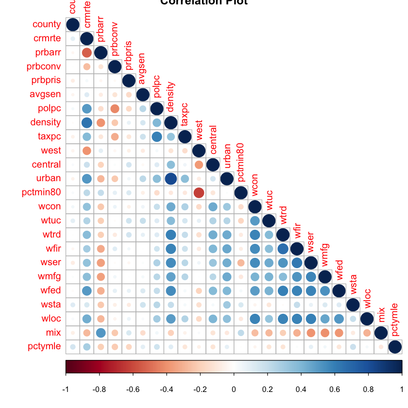

```r
correlations <- cor(data)
corrplot(correlations, type="lower", method='circle', main="Correlation Plot")
```

We do see that the following variables are most correlated with crime rate:

- wage related variables: `wcon`, `wtuc`, `wtrd`, `wfir`, `wser`, `wmfg`, `wfed`, `wsta`, `wloc`
- population density variables
- police presence and conviction variables

Our first model will only look at crime rate regressed on the wage in government jobs, `wfed`, `wsta`, `wloc`. However, as this does not take into account of important latent variables that also have a strong impact on crime (e.g., population density, police presence, tax rate), we build a second model with both the wage variable and key co-variates included. This way, we are able to isolate the effect of wages on crime without the interference of some of the key latent variables.

Lastly, we create a larger model with all of the main variables included to further isolate the effect of wages on crime. After each model, we will discuss the potential effects of omitted latent variables that we either have not yet included into the model or do not have data for.

Note that for our non-wage-related variables, we transform them (e.g., log, sqrt) as necessary to optimize the strength of their relationship with crime rate. Even though, it reduces the explainability of the non-wage-related variables, our key focus is on the effect of wages on crime anyway. By controlling as much as possible for the effect of other variables (by optimally transforming them to have a strong linear relationship with crime rate), we can focus more on the incremental impact of wages on crime. In other words, we are controlling for otherwise omitted latent relationships (e.g., non-linear) from other variables that may be affecting our wage variables.

We will need to take a closer look at our wage and crime rate variables in the section below before determining whether we want to transform them (e.g., potentially for a more robust model) or keep them untransformed (e.g., potentially for easier interpretability).

Note that we've chosen to exclude the following columns:

- `urban`
- `county`
- `mix`

We exclude `urban` because it is defined as basically a calculated variable from `density` (based on the definition given in Cornwell & Trumball). We exclude county because it is an identifier column and not a characteristic. And lastly, we exclude `mix` because it is a descriptor of types of crime and thus not a possible causal variable of crime itself.

# Model 1

We first take a look at the distribution of each of our variables. They all look roughly normal although there is some right skew in `crmrte`. `wfed`, `wsta`, and `wloc` are all roughly normally distributed.

Because we have a large sample, the right skew in `crmrte` should not be an issue due to the CLT. Nonetheless, we take a look at the log transformed version of `crmrte` and see that it is significantly more normal. Because we are able to keep our interpretability even with a log transform, we decide to do so.

We see that the log transformed wage variables have a similar distribution to what they had prior to the transformation. Because they do not seem to become more skewed and because a log-transform of wages helps for interpretability (e.g., \$300 increase may be small when you're earning \\$5000 but large when you're earning \$100), we decide to log-transform the three wage variables as well. When we log-transform, we're looking at the change in percentage rather than change in absolute number, which makes sense for wages (e.g., 10% increase in wages).

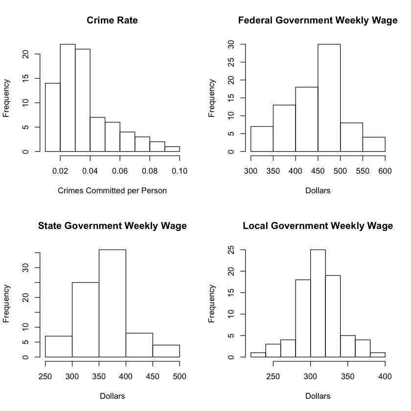

```r
par(mfrow=c(2,2))
hist(data$crmrte, main = "Crime Rate", xlab = "Crimes Committed per Person")
hist(data$wfed, main = "Federal Government Weekly Wage", xlab = "Dollars")
hist(data$wsta, main = "State Government Weekly Wage", xlab = "Dollars")
hist(data$wloc, main = "Local Government Weekly Wage", xlab = "Dollars")
```

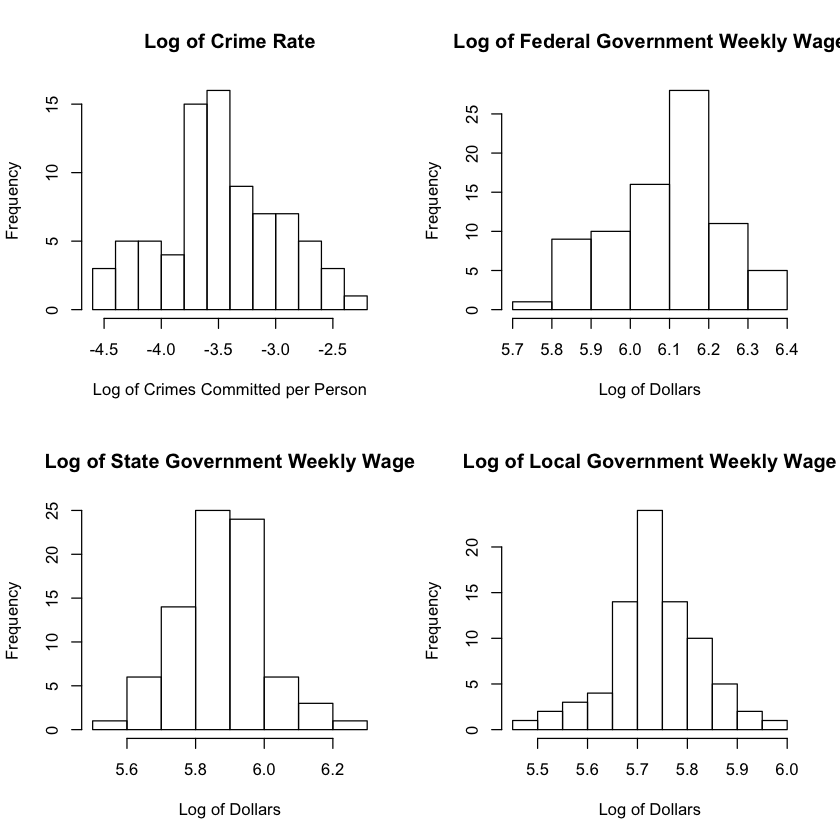

```r
par(mfrow=c(2,2))
hist(log(data$crmrte), main = "Log of Crime Rate", xlab = "Log of Crimes Committed per Person")
hist(log(data$wfed), main = "Log of Federal Government Weekly Wage", xlab = "Log of Dollars")
hist(log(data$wsta), main = "Log of State Government Weekly Wage", xlab = "Log of Dollars")
hist(log(data$wloc), main = "Log of Local Government Weekly Wage", xlab = "Log of Dollars")
data$crmrte = log(data$crmrte)
data$wfed = log(data$wfed)
data$wsta = log(data$wsta)
data$wloc = log(data$wloc)
```

Our first model regresses crime rate on the average weekly wage of different government jobs. We see that these variables are able to explain about 27% of the variability in the crime rate (based on adjusted R2).

Next, we'll want to confirm the MLR assumptions before continuing in our analysis and interpretation.

```r
model = lm(crmrte ~ wfed + wsta + wloc, data=data)
model_summary = summary(model)
paste('Adjusted R-Squared is', model_summary$adj.r.squared)
model_summary
```

'Adjusted R-Squared is 0.27581260132406'

```
Call:
lm(formula = crmrte ~ wfed + wsta + wloc, data = data)

Residuals:
    Min      1Q  Median      3Q     Max
-1.1089 -0.2597 -0.0354  0.2450  1.2293

Coefficients:
            Estimate Std. Error t value Pr(>|t|)
(Intercept) -20.5176     3.6298  -5.653 2.63e-07 ***
wfed          1.3981     0.4056   3.447 0.000928 ***
wsta          0.2121     0.4205   0.504 0.615426
wloc          1.2711     0.6329   2.008 0.048159 *
---
Signif. codes:  0 ‘***’ 0.001 ‘**’ 0.01 ‘*’ 0.05 ‘.’ 0.1 ‘ ’ 1

Residual standard error: 0.4321 on 76 degrees of freedom
Multiple R-squared:  0.3033,	Adjusted R-squared:  0.2758
F-statistic: 11.03 on 3 and 76 DF,  p-value: 4.318e-06
```

### Analysis of CLM assumptions:

#### Following are the CLM assumptions:

1. Linear population model
2. Random Sampling
3. No perfect multicollinearity
4. Zero-conditional mean
5. Homoskedasticity
6. Normality of Errors

#### Following first two assumptions should hold for all subsequent linear models:

1. **Linear population model:** we have created a linear population model using lm() and hence the condition of linearity of coefficients is satisfied
2. **Random Sampling:** we are entirely certain whether or not this data is randomly sampled. Even though we have 90 out of 100 counties represented in our dataset, the summary statistics for each of the counties may or may not have been randomly sampled. For example, for wages, it is unclear whether the researchers had sampled wages from the richest areas in a county or whether wages was truly randomly sampled. Even though we cannot confirm that the data is i.i.d., for the remainder of the model, we will place our faith in Cornwell and Trumbull and assume that the data is randomly sampled.
3. **No perfect multicollinearity:** we have created correlation tables below and do not find any values of 1 between different variables, hence the no perfect multicollinearity assumption holds too.

```r
cor(data[c('wfed', 'wsta', 'wloc')])
```

|  | wfed | wsta | wloc |
| --- | --- | --- | --- |
| wfed | 1.000000 | 0.1167490 | 0.5183780 |
| wsta | 0.116749 | 1.0000000 | 0.1970533 |
| wloc | 0.518378 | 0.1970533 | 1.0000000 |

#### Following tests applied for zero-conditional mean and homoskedasticity error assumptions:

1. **Zero-conditional mean**: In the Residuals vs Fitted plot, we see that the red smoothing line is almost flat, indicating that the conditional mean is roughly zero
2. **Homoskedasticity**: In the Scale-Location plot we see that the smoothing line has a bit of a U-bend shape, which indicates that there may be a bit of heteroskedasticity. The Breusch-Pagan test indicates a p-value < 0.05, leading us to reject the null hypothesis of homoskedasticity. Thus, we will use the heteroskedastic robust errors.
3. **Normality of Errors:** Our QQ plot shows evidence of some non-normality, but is overall relatively normal as most of the points show up on the diagonal line. The Shapiro-Wilk test shows a p-value > 0.05, meaning we cannot reject the null hypothesis that our errors are normal.

```
	studentized Breusch-Pagan test

data:  model
BP = 17.973, df = 3, p-value = 0.0004455
```

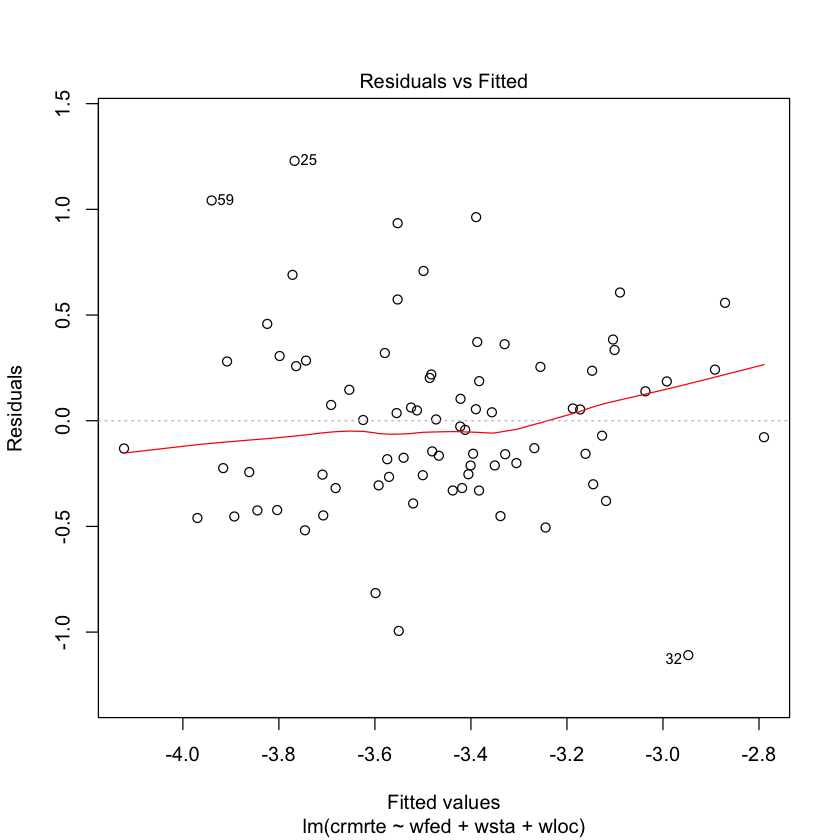

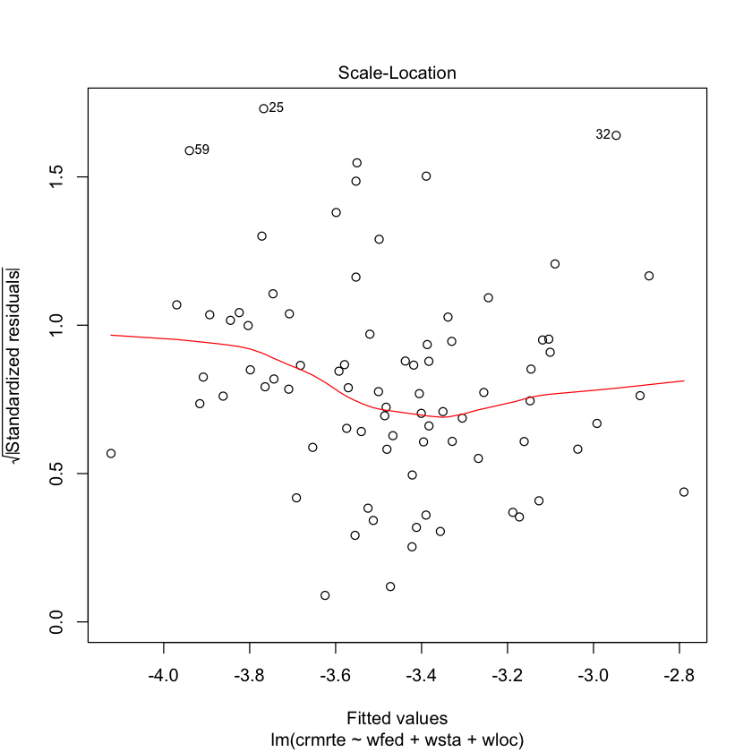

```r
plot(model, which = 1)
bptest(model)
plot(model, which = 3)
```

```
	Shapiro-Wilk normality test

data:  model$residuals
W = 0.97185, p-value = 0.07445
```

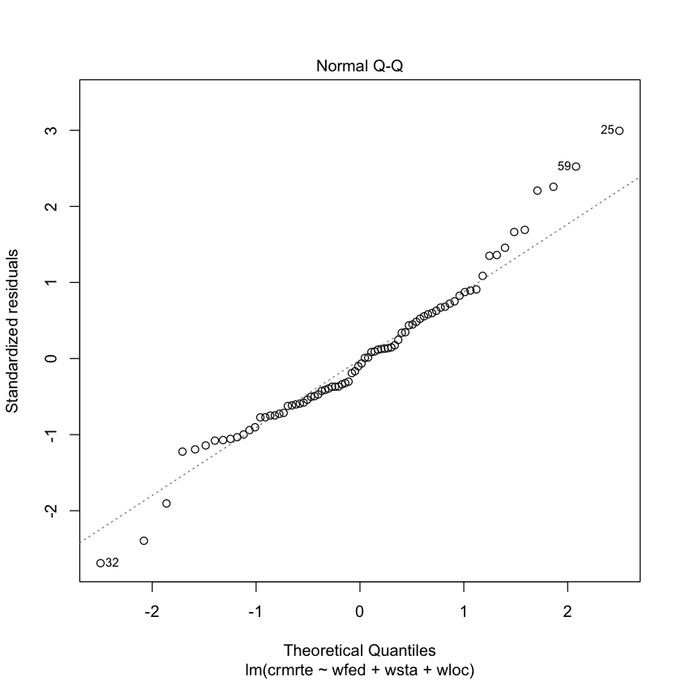

```r
shapiro.test(model$residuals)
plot(model, which = 2)
```

After accounting for heteroskedasticity using robust standard errors, we see that `wfed` is our significicant variable. In particular, it seems that every 1% increase in federal wages seems to correlate with a 1.4% increase in crime rate. The `wsta` and `wloc` features are not significant in this model. However, as we will discuss below, the counterintuitive result with higher wages correlating with higher crime is likely due to hidden variables that were not included in this model.

```r
se.model1 = coeftest(model, vcov = vcovHC)[ , "Std. Error"]
coeftest(model, vcov = vcovHC)
```

```
t test of coefficients:

             Estimate Std. Error t value  Pr(>|t|)
(Intercept) -20.51759    4.00493 -5.1231 2.213e-06 ***
wfed          1.39805    0.62840  2.2248   0.02906 *
wsta          0.21211    0.34085  0.6223   0.53561
wloc          1.27110    0.91156  1.3944   0.16726
---
Signif. codes:  0 ‘***’ 0.001 ‘**’ 0.01 ‘*’ 0.05 ‘.’ 0.1 ‘ ’ 1
```

Some of the major omitted variables that we believe could have a significant impact on crime rates include the population density, the police presence within an area, and the tax per capita.

In order to control for some of the effects of the omitted variables, we next create a second model with our model-1 coefficients in addition to:

- `taxpc`
- `polpc`
- `density`

Therefore: `Model 2 = Model 1 + taxpc, density, polpc`

# Model 2

In our second model, we want to control for the effect of the hidden variables that may be artificially increasing the modeled effect of our government wage variables in model one. Therefore, we add in `taxpc`, `density`, and `polpc` to control for these effects.

Above, we had discussed the potential effect of each additional variable on crime rate. In our modeling below, we'll be assessing each of the model coefficients for taxpc, density, and polpc to determine the actual effect of each feature on crime (positive or negative) as well as the strength of the effect.

Once again, we take a look at a histogram of our new variables. While tax per capita, density, police per capita are all right skewed. We can see that the log transforms of the tax per capita and police per capita are slightly more normally distributed, so we take the log of those features. We leave density untransformed.

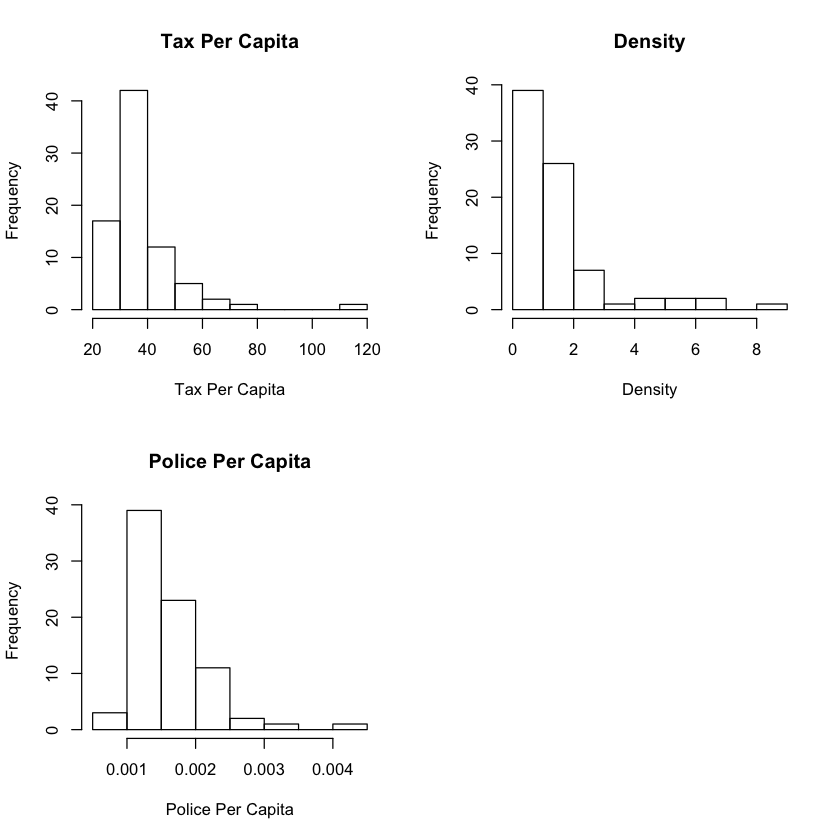

```r
par(mfrow=c(2,2))
hist((data$taxpc), main = "Tax Per Capita", xlab = "Tax Per Capita")
hist((data$density), main = "Density", xlab = "Density")
hist((data$polpc), main = "Police Per Capita", xlab = "Police Per Capita")
```

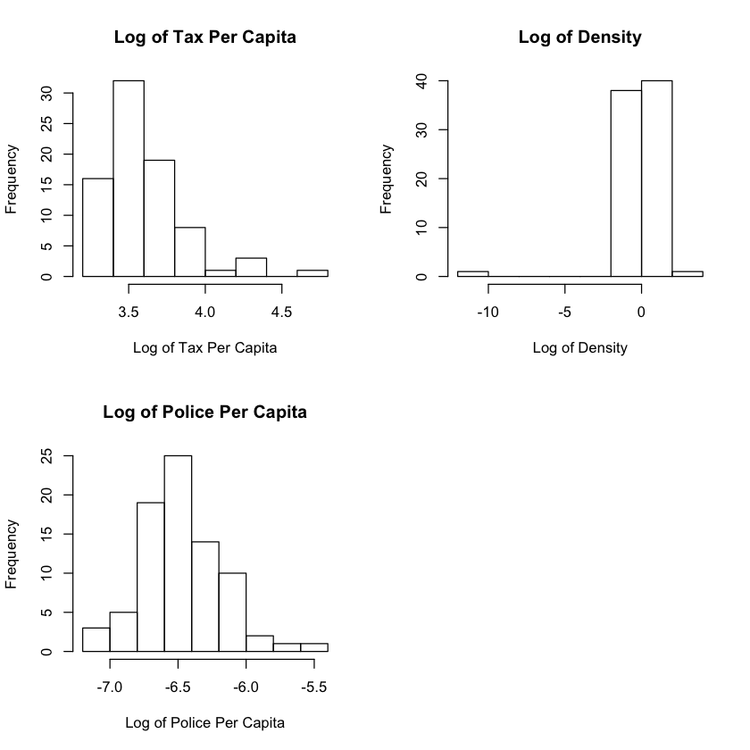

```r
par(mfrow=c(2,2))
hist(log(data$taxpc), main = "Log of Tax Per Capita", xlab = "Log of Tax Per Capita")
hist(log(data$density), main = "Log of Density", xlab = "Log of Density")
hist(log(data$polpc), main = "Log of Police Per Capita", xlab = "Log of Police Per Capita")
data$taxpc = log(data$taxpc)
data$polpc = log(data$polpc)
```

Running a new model with the our new variables shows that these features together are able to explain about 50% of the variation in the crime rate (based on the adjusted R-squared). In particular, now that we have controlled for the effect of taxpc, density, and polpc, we see that federal wages and local wages seem to have a slight positive effect on crime rate, while state wages has a slight negative effect on crime rate. Taxpc, desnity, and polpc all appear to have a positive effect on crime rate.

Prior to looking at significance of the features, we first re-evaluate our CLM assumptions.

```r
secondary_model = lm(crmrte ~ wfed + wsta + wloc + taxpc + density + polpc, data=data)
secondary_model_summary = summary(secondary_model)
c('Adjusted R-Squared is', secondary_model_summary$adj.r.squared)
secondary_model_summary
```

1. 'Adjusted R-Squared is'

2. '0.502241677607275'

```
Call:
lm(formula = crmrte ~ wfed + wsta + wloc + taxpc + density +
    polpc, data = data)

Residuals:
     Min       1Q   Median       3Q      Max
-0.88164 -0.18344 -0.06344  0.20746  0.79100

Coefficients:
            Estimate Std. Error t value Pr(>|t|)
(Intercept) -5.50668    4.18368  -1.316  0.19222
wfed         0.65855    0.37898   1.738  0.08648 .
wsta        -0.13205    0.35454  -0.372  0.71063
wloc         0.32044    0.55314   0.579  0.56416
taxpc        0.06920    0.18780   0.368  0.71358
density      0.11683    0.03474   3.363  0.00123 **
polpc        0.53398    0.16888   3.162  0.00228 **
---
Signif. codes:  0 ‘***’ 0.001 ‘**’ 0.01 ‘*’ 0.05 ‘.’ 0.1 ‘ ’ 1

Residual standard error: 0.3582 on 73 degrees of freedom
Multiple R-squared:   0.54,	Adjusted R-squared:  0.5022
F-statistic: 14.29 on 6 and 73 DF,  p-value: 1.077e-10
```

### Analysis of CLM assumptions:

#### Following are the CLM assumptions:

1. Linear population model
2. Random Sampling
3. No perfect multicollinearity
4. Zero-conditional mean
5. Homoskedasticity
6. Normality of Errors

#### Following first two assumptions should hold for all subsequent linear models:

1. **Linear population model:** we have created a linear population model using lm() and hence the condition of linearity of coefficients is satisfied
2. **Random Sampling:** we are entirely certain whether or not this data is randomly sampled. Even though we have 90 out of 100 counties represented in our dataset, the summary statistics for each of the counties may or may not have been randomly sampled. Please refer to model 1 for a more in depth explanation.
3. **No perfect multicollinearity:** we have created correlation tables below and do not find any values of 1 between different variables, hence the no perfect multicollinearity assumption holds too.

```r
cor(data[c('wfed', 'wsta', 'wloc', 'taxpc', 'density', 'polpc')])
```

|  | wfed | wsta | wloc | taxpc | density | polpc |
| --- | --- | --- | --- | --- | --- | --- |
| wfed | 1.00000000 | 0.11674904 | 0.5183780 | 0.08391372 | 0.5525642 | 0.3080924 |
| wsta | 0.11674904 | 1.00000000 | 0.1970533 | 0.06801479 | 0.2024831 | 0.1937667 |
| wloc | 0.51837803 | 0.19705329 | 1.0000000 | 0.26681358 | 0.4926037 | 0.3256986 |
| taxpc | 0.08391372 | 0.06801479 | 0.2668136 | 1.00000000 | 0.3786291 | 0.5032964 |
| density | 0.55256418 | 0.20248306 | 0.4926037 | 0.37862906 | 1.0000000 | 0.4533510 |
| polpc | 0.30809241 | 0.19376666 | 0.3256986 | 0.50329639 | 0.4533510 | 1.0000000 |

#### Following tests applied for zero-conditional mean and homoskedasticity error assumptions:

1. **Zero-conditional mean**: In the Residuals vs Fitted plot, we see that the red smoothing line is almost flat, indicating that the conditional mean is roughly zero. Though there is some deviation, it is not huge.
2. **Homoskedasticity**: In the Scale-Location plot we see that the smoothing line has a definite slant, indicating that the variance of the errors decreases as the predicted values go up.. The Breusch-Pagan test indicates a p-value < 0.05, leading us to reject the null hypothesis of homoskedasticity. Thus, we will use the heteroskedastic robust errors.
3. **Normality of Errors:** Our QQ plot shows evidence of some non-normality, but is overall relatively normal as most of the points show up on the diagonal line. The Shapiro-Wilk test shows a p-value > 0.05, meaning we cannot reject the null hypothesis that our errors are normal.

```
	studentized Breusch-Pagan test

data:  secondary_model
BP = 28.02, df = 6, p-value = 9.314e-05
```

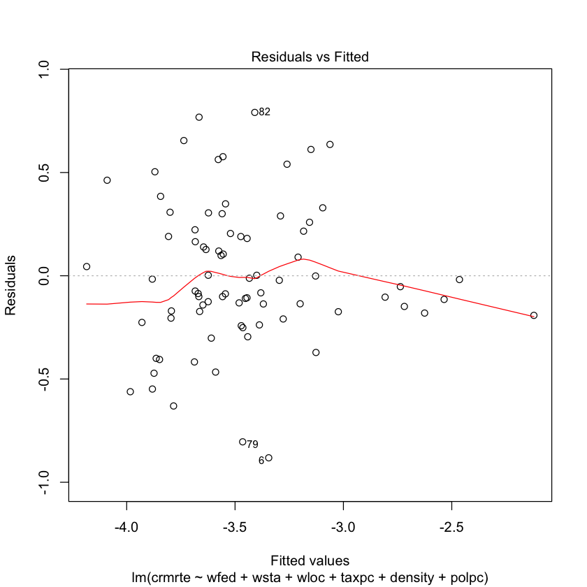

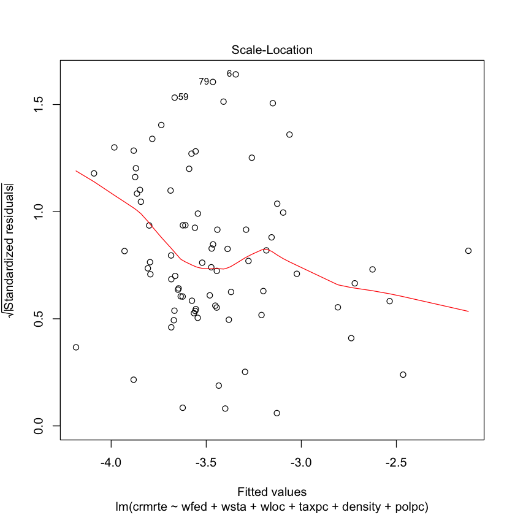

```r
plot(secondary_model, which = 1)
bptest(secondary_model)
plot(secondary_model, which = 3)
```

```
	Shapiro-Wilk normality test

data:  secondary_model$residuals
W = 0.9829, p-value = 0.3628
```

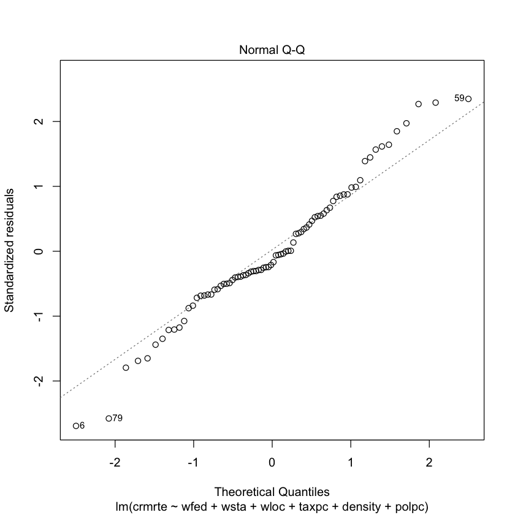

```r
shapiro.test(secondary_model$residuals)
plot(secondary_model, which = 2)
```

In particular, we note that once we control for density, polpc, and taxpc, it seems that the government wages do not have a significant effect on the crime rate within a county, which, for our policy decisions, seems to indicate that raising government wages will not have an effect on crime rates. Instead, it seems that policies geared toward enticing people toward suburbs to decrease the population in the highest crime rate, urban populations may help reduce the crime rate a decent amount. Before we come to any firm conclusions though, we need to consider additional hidden variables.

In particular, we look at:

- **`pctymle`:** because young males tend to be more pre-disposed to criminal activity, they will tend to have a positive effect on crime rate. At the same time, they tend to be earlier in their careers and will have lower wages.
- **`prbconv` and `prbarr`:** because a higher arrest rate and higher conviction rate make the potential cost of committing a crime significantly higher, we believe that this is likely negatively correlated with crime. In adddition, higher government wages may indicate a more stringent government, potentially correlated with a higher conviction and arrest rate.

```r
se.model2 = coeftest(secondary_model, vcov = vcovHC)[ , "Std. Error"]
coeftest(secondary_model, vcov = vcovHC)
```

```
t test of coefficients:

             Estimate Std. Error t value Pr(>|t|)
(Intercept) -5.506676   6.688494 -0.8233 0.413016
wfed         0.658548   0.632406  1.0413 0.301156
wsta        -0.132053   0.342382 -0.3857 0.700848
wloc         0.320442   0.736115  0.4353 0.664618
taxpc        0.069202   0.307621  0.2250 0.822640
density      0.116830   0.042742  2.7334 0.007859 **
polpc        0.533982   0.323826  1.6490 0.103449
---
Signif. codes:  0 ‘***’ 0.001 ‘**’ 0.01 ‘*’ 0.05 ‘.’ 0.1 ‘ ’ 1
```

# Model 3

Lastly, we will turn to the following remaining variables to create a final model with additional features that we believe might affect crime rate, even if we believe the effect may be minimal:

- `pctymle`
- `prbconv`
- `prbarr`

Our final model is: `Model 3 = Model 2 + pctymle, prbconv, prbarr`

We wanted to include these variables that we believe potentially have a strong effect on crime rates in order to decrease the effects of omitted variable bias.

Once again, we take a look at a histogram of our new variables. We can see that the probability of conviction and arrest are pretty normally distributed. While percent young male is right skewed, we decide not to transform this variable as log, sqrt, etc. transforms of this percentage variable decrease explainability drastically.

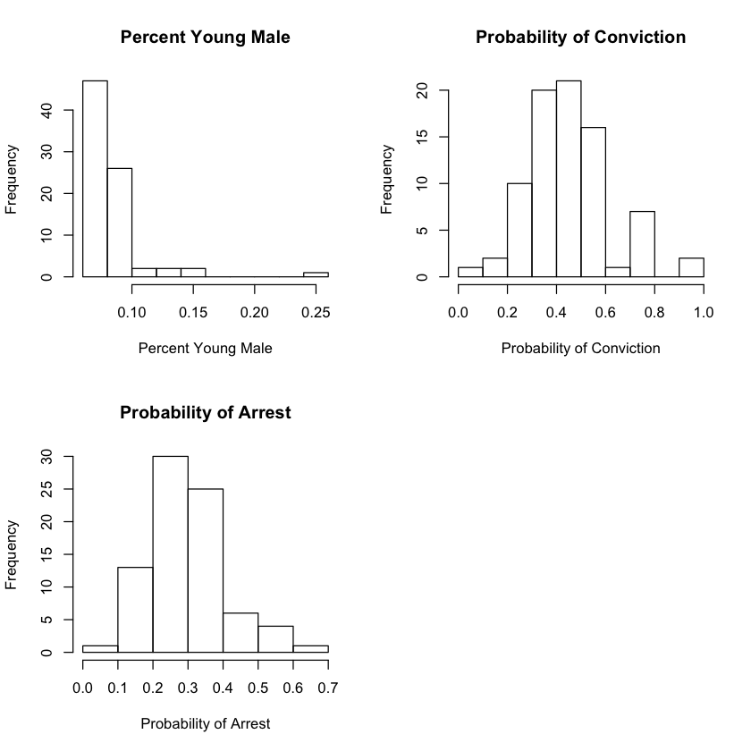

```r
par(mfrow=c(2,2))
hist((data$pctymle), main = "Percent Young Male", xlab = "Percent Young Male")
hist((data$prbconv), main = "Probability of Conviction", xlab = "Probability of Conviction")
hist((data$prbarr), main = "Probability of Arrest", xlab = "Probability of Arrest")
```

Running a new model with the our new variables shows that these features together are able to explain about 62% of the variation in the crime rate (based on the adjusted R-squared). In particular, now that we have controlled for the effect of taxpc, density, polpc, pctymle, prbarr, and prbconv, we see that federal wages and local wages continue to have a slight positive effect on crime rate, while state wages has a slight negative effect on crime rate. While prbarr and prbconv have negative effects on crime rate, as we had expected, polpc and taxpc seem to have positive effects on crime rate, contrary to our initial thoughts.

Prior to looking at significance of the features, we first re-evaluate our CLM assumptions.

```r
tertiary_model = lm(crmrte ~ wfed + wsta + wloc + taxpc + density + polpc + pctymle + prbarr
                    + prbconv, data=data)
tertiary_model_summary = summary(tertiary_model)
paste('Adjusted R-Squared is', tertiary_model_summary$adj.r.squared)
tertiary_model_summary
```

'Adjusted R-Squared is 0.623945761715149'

```
Call:
lm(formula = crmrte ~ wfed + wsta + wloc + taxpc + density +
    polpc + pctymle + prbarr + prbconv, data = data)

Residuals:
     Min       1Q   Median       3Q      Max
-0.71304 -0.17816 -0.00378  0.15995  0.62553

Coefficients:
            Estimate Std. Error t value Pr(>|t|)
(Intercept) -5.93972    3.88102  -1.530 0.130412
wfed         0.93883    0.35456   2.648 0.010001 *
wsta        -0.41600    0.31333  -1.328 0.188608
wloc         0.12112    0.48321   0.251 0.802805
taxpc        0.23915    0.17524   1.365 0.176715
density      0.06469    0.03209   2.016 0.047647 *
polpc        0.34238    0.16162   2.118 0.037687 *
pctymle      4.05464    1.69527   2.392 0.019459 *
prbarr      -1.45807    0.37625  -3.875 0.000237 ***
prbconv     -0.32252    0.24853  -1.298 0.198646
---
Signif. codes:  0 ‘***’ 0.001 ‘**’ 0.01 ‘*’ 0.05 ‘.’ 0.1 ‘ ’ 1

Residual standard error: 0.3114 on 70 degrees of freedom
Multiple R-squared:  0.6668,	Adjusted R-squared:  0.6239
F-statistic: 15.56 on 9 and 70 DF,  p-value: 1.359e-13
```

### Analysis of CLM assumptions:

#### Following are the CLM assumptions:

1. Linear population model
2. Random Sampling
3. No perfect multicollinearity
4. Zero-conditional mean
5. Homoskedasticity
6. Normality of Errors

#### Analysis:

1. **Linear population model:** we have created a linear population model using lm() and hence the condition of linearity of coefficients is satisfied
2. **Random Sampling:** we are entirely certain whether or not this data is randomly sampled. Even though we have 90 out of 100 counties represented in our dataset, the summary statistics for each of the counties may or may not have been randomly sampled. Please refer to model 1 for a more in depth explanation.
3. **No perfect multicollinearity:** we have created correlation tables below and do not find any values of 1 between different variables, hence the no perfect multicollinearity assumption holds too.

```r
cor(data[c('wfed', 'wsta', 'wloc', 'taxpc', 'density', 'polpc', 'prbarr', 'prbconv', 'pctymle')])
```

|  | wfed | wsta | wloc | taxpc | density | polpc | prbarr | prbconv | pctymle |
| --- | --- | --- | --- | --- | --- | --- | --- | --- | --- |
| wfed | 1.00000000 | 0.11674904 | 0.51837803 | 0.08391372 | 0.5525642 | 0.3080924 | -0.30854247 | 0.08597240 | -0.10900894 |
| wsta | 0.11674904 | 1.00000000 | 0.19705329 | 0.06801479 | 0.2024831 | 0.1937667 | -0.22439706 | -0.06870971 | 0.18239852 |
| wloc | 0.51837803 | 0.19705329 | 1.00000000 | 0.26681358 | 0.4926037 | 0.3256986 | -0.28905855 | -0.04952080 | 0.03259021 |
| taxpc | 0.08391372 | 0.06801479 | 0.26681358 | 1.00000000 | 0.3786291 | 0.5032964 | -0.07779716 | -0.34294493 | -0.12330745 |
| density | 0.55256418 | 0.20248306 | 0.49260374 | 0.37862906 | 1.0000000 | 0.4533510 | -0.39247462 | -0.22939736 | 0.10979088 |
| polpc | 0.30809241 | 0.19376666 | 0.32569860 | 0.50329639 | 0.4533510 | 1.0000000 | -0.18356513 | -0.42837170 | 0.20156174 |
| prbarr | -0.30854247 | -0.22439706 | -0.28905855 | -0.07779716 | -0.3924746 | -0.1835651 | 1.00000000 | -0.11877828 | -0.20858322 |
| prbconv | 0.08597240 | -0.06870971 | -0.04952080 | -0.34294493 | -0.2293974 | -0.4283717 | -0.11877828 | 1.00000000 | -0.21520553 |
| pctymle | -0.10900894 | 0.18239852 | 0.03259021 | -0.12330745 | 0.1097909 | 0.2015617 | -0.20858322 | -0.21520553 | 1.00000000 |

#### Following tests applied for zero-conditional mean and homoskedasticity error assumptions:

1. **Zero-conditional mean**: In the Residuals vs Fitted plot, we see that the red smoothing line is almost flat, indicating that the conditional mean is roughly zero. Though there is some deviation, it is not huge.
2. **Homoskedasticity**: In the Scale-Location plot we see that the smoothing line has a definite slant, indicating that the variance of the errors decreases as the predicted values go up.. The Breusch-Pagan test indicates a p-value < 0.05, leading us to reject the null hypothesis of homoskedasticity. Thus, we will use the heteroskedastic robust errors.
3. **Normality of Errors:** Our QQ plot shows evidence of some non-normality, but is overall relatively normal as most of the points show up on the diagonal line. The Shapiro-Wilk test shows a p-value > 0.05, meaning we cannot reject the null hypothesis that our errors are normal.

```
	studentized Breusch-Pagan test

data:  tertiary_model
BP = 22.195, df = 9, p-value = 0.008283
```

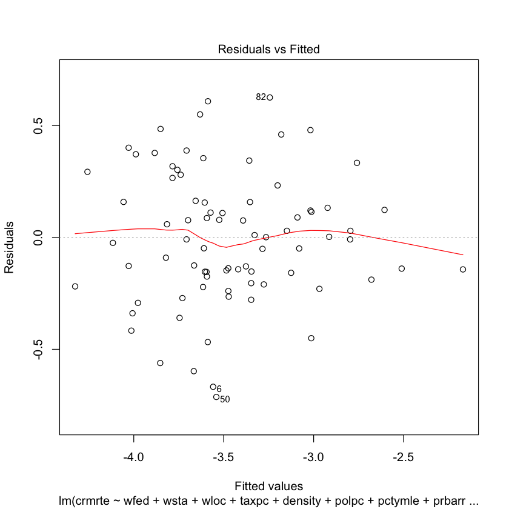

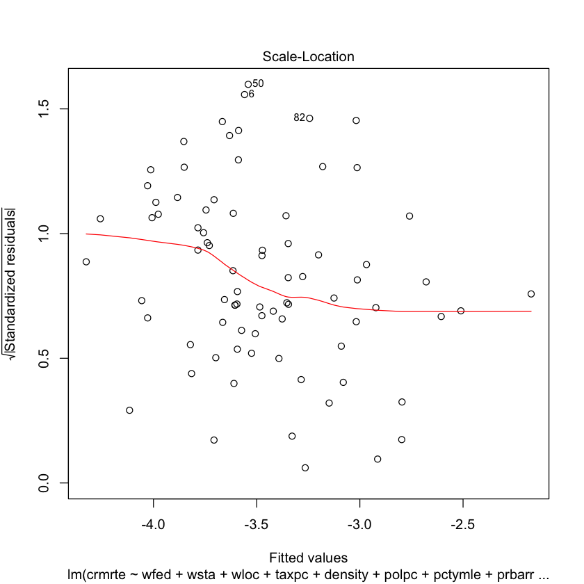

```r
plot(tertiary_model, which = 1)
bptest(tertiary_model)
plot(tertiary_model, which = 3)
```

```
	Shapiro-Wilk normality test

data:  tertiary_model$residuals
W = 0.98777, p-value = 0.6493
```

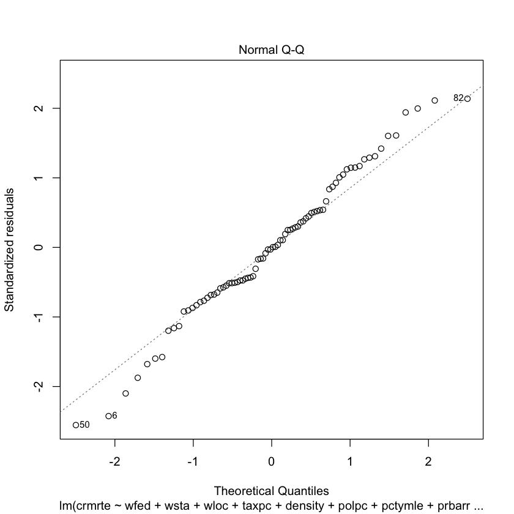

```r
shapiro.test(tertiary_model$residuals)
plot(tertiary_model, which = 2)
```

After accounting for heteroskedasticity using robust standard errors, we see that prbarr and pctymle are the most significant features potentially effecting crime rate followed by density and wfed.

```r
se.model3 = coeftest(tertiary_model, vcov = vcovHC)[ , "Std. Error"]
coeftest(tertiary_model, vcov = vcovHC)
```

```
t test of coefficients:

             Estimate Std. Error t value Pr(>|t|)
(Intercept) -5.939717   5.851430 -1.0151  0.31356
wfed         0.938825   0.484038  1.9396  0.05646 .
wsta        -0.415998   0.292280 -1.4233  0.15910
wloc         0.121124   0.715833  0.1692  0.86612
taxpc        0.239146   0.261515  0.9145  0.36361
density      0.064685   0.034945  1.8511  0.06838 .
polpc        0.342376   0.256976  1.3323  0.18707
pctymle      4.054635   2.014597  2.0126  0.04800 *
prbarr      -1.458066   0.540969 -2.6953  0.00880 **
prbconv     -0.322525   0.361114 -0.8931  0.37484
---
Signif. codes:  0 ‘***’ 0.001 ‘**’ 0.01 ‘*’ 0.05 ‘.’ 0.1 ‘ ’ 1
```

# Conclusion and recommendations

Overall, despite having included iteratively more variables into our model, there are still a significant number of omitted variables that may be confounding our research.

The following sources of omitted variable bias will tend to have positive correlation with crime rate:

- Gang activity: gangs tend to be direct causes of crime in regions where they are based, regardless of the economic prosperity, density, or arrest rates in that region. Even though some of these factors may push the level of gang activity up or down, it makes sense that gang activity will always have a positive effect on crime.
- Unemployment rate: if you are unemployed you tend to have less money, and having less money will increase the chance that one might commit a crime. Poorer areas tend to have more crime.
- Single parenthood: less oversight of young males may lead these individuals to become more reckless and potentially show less regard for others as well as property, leading to higher crime rates
- Guns per capita: easier access to weapons may lead to a higher propensity to commit crimes

The following sources of omitted variable bias may have negative correlation with crime rate:

- Education rate: higher high school graduation rate usually means that most students learn to stay out of trouble during their formative years and onward, leading to lower crime
- Health care: easier access to healthcare may lead to 1) better mental health among citizens 2) fewer issues with drug addiction both potentially leading to lower crime rates
- Weather: because there are more opportunities to be outside in good climates, where groups of strangers may congregate, there will be potentially higher crime rates in warmer climates. On the flip side, in colder climates, people tend to stay in-doors, decreasing the chance that they will commit a crime

In our initial basic model, `wfed`, the federal wages seems to have a significant positive effect on crime rate. However, it becomes evident that part of that significance is due to omitted variables as in the second model, density and police presence seem to have significant effects instead.

Ultimately, in our third model, we see that the probability of arrest and percentage of young males have the highest statistical significance followed by density and wfed.

```r
stargazer(model, secondary_model, tertiary_model, type = "text", omit.stat = "f",
          se = list(se.model1, se.model2, se.model3))
```

```
===================================================================
                                  Dependent variable:
                    -----------------------------------------------
                                        crmrte
                          (1)             (2)             (3)
-------------------------------------------------------------------
wfed                    1.398**          0.659          0.939*
                        (0.628)         (0.632)         (0.484)

wsta                     0.212          -0.132          -0.416
                        (0.341)         (0.342)         (0.292)

wloc                     1.271           0.320           0.121
                        (0.912)         (0.736)         (0.716)

taxpc                                    0.069           0.239
                                        (0.308)         (0.262)

density                                0.117***         0.065*
                                        (0.043)         (0.035)

polpc                                   0.534*           0.342
                                        (0.324)         (0.257)

pctymle                                                 4.055**
                                                        (2.015)

prbarr                                                 -1.458***
                                                        (0.541)

prbconv                                                 -0.323
                                                        (0.361)

Constant              -20.518***        -5.507          -5.940
                        (4.005)         (6.688)         (5.851)

-------------------------------------------------------------------
Observations              80              80              80
R2                       0.303           0.540           0.667
Adjusted R2              0.276           0.502           0.624
Residual Std. Error 0.432 (df = 76) 0.358 (df = 73) 0.311 (df = 70)
===================================================================
Note:                                   *p<0.1; **p<0.05; ***p<0.01
```

### Policy recommendations

Originally we were exploring the idea that whether government wages in the North Carolina congressional districts were related to crime statistics in the state. We were hoping to find a possible statistical significance of wages on crime rates, through which we could implement some economic or social sector programs related to jobs and labor growth.

However, we were not able to find a strong statistical or practical effect of state or local wages on crime. While federal wages did seem to have a strong positive effect on crime, we believe that that is likely due to omitted variable bias as it is not immediately clear why federal wages would lead to higher crime.

Instead, we found that population density has a relatively strong effect on crime rates. Thus, we recommend encourage a rejuvenation of suburban and exurban areas around bigger cities to promote the decrease urban congestion and thereby reduce population density of the area:

- Housing subsidies for individuals moving into suburbs from urban areas
- Investing in community centers / restaurants / malls in suburbs to entice citizens to move
- Increasing public transit to make the commute in and out of the suburbs more convenient